# 時系列分析 第 11 回

VECM

Kenichiro Tamaki

2022 年 6 月 20 日

# 1 パッケージ

必要なパッケージは次である.

```r
library(readr) # ファイルの読込
library(quantmod) # 時系列データに変換
library(vars) # VAR
library(urca) # 単位根検定, 共和分検定
```

# 2 関数の作成

自作関数は次である.

**VAR の残差に対するかばん検定**

```r
port.v <- function(x, lag) { # x = 推定結果, lag = ラグ
  res <- serial.test(x, lags.pt = lag, type = "PT.adjusted") # かばん検定
  res <- c(lag, res$serial$statistic, res$serial$parameter, res$serial$p.value) # ラグ, 検定統計量, 自由度, p 値

  return(res)
}
```

# 3 データの概要

日経平均株価を用いて, 現物と先物の関係を分析する.

## 3.1 データの入手と編集

[Investing.com](https://jp.investing.com/) から次のデータを取得する.

- 日経平均株価 (日経 225)  
  https://jp.investing.com/indices/japan-ni225
- 日経 225 先物  
  https://jp.investing.com/indices/japan-225-futures

```r
N225s <- read_csv("N225s.csv") # 日経平均株価
N225f <- read_csv("N225f.csv") # 日経 225 先物
```

データを確認する.

```r
head(N225s, 5) # 日経平均株価の最初の 5 個を表示
```

```
## # A tibble: 5 x 7
##   日付け      終値   始値   高値   安値 出来高  `変化率 %`
##   <chr>      <dbl>  <dbl>  <dbl>  <dbl> <chr>   <chr>
## 1 2022/6/17 25963  25988. 26072. 25721. 1.15B   -1.77%
## 2 2022/6/16 26431. 26716. 26948. 26431. 678.27M 0.40%
## 3 2022/6/15 26326. 26626. 26639. 26322. 727.41M -1.14%
## 4 2022/6/14 26630. 26556. 26658. 26358. 750.15M -1.32%
## 5 2022/6/13 26987. 27370. 27389. 26948. 713.59M -3.01%
```

```r
tail(N225f, 5) # 日経 225 先物の最後の 5 個を表示
```

```
## # A tibble: 5 x 7
##   日付け    終値  始値  高値  安値 出来高 `変化率 %`
##   <chr>    <dbl> <dbl> <dbl> <dbl> <chr>  <chr>
## 1 2018/1/7 23890 23805 23900 23795 -      0.72%
## 2 2018/1/5 23720 23430 23730 23420 66.21K 1.32%
## 3 2018/1/4 23410 22760 23490 22720 68.02K 1.20%
## 4 2018/1/3 23133 22830 23213 22810 -      1.35%
## 5 2018/1/2 22825 22840 22900 22615 -      0.33%
```

日付と終値のみを取り出し, 時系列データに変換する.

```r
n225s <- N225s[,1:2] # 日付と終値のみを取り出す
n225f <- N225f[,1:2]
n225s <- as.xts(read.zoo(n225s)) # 時系列データに変換
n225f <- as.xts(read.zoo(n225f))
```

標本数は次である.

```r
(T <- length(n225s)) # 日経平均株価の標本数
```

```
## [1] 1085
```

```r
length(n225f) # 日経 225 先物の標本数
```

```
## [1] 1195
```

標本数が異なるので, 日経平均株価に合わせて日経 225 先物を削除する.

```r
n225 <- cbind(log(n225s), log(n225f)) # データを結合
names(n225) <- c("log.n225s", "log.n225f") # 名称を変更
sum(is.na(n225)) # 欠損数
```

```
## [1] 110
```

```r
n225 <- na.omit(n225) # 欠損値を削除
```

データを確認する.

```r
head(n225, 5) # 最初の 5 個を表示
```

```
##            log.n225s log.n225f
## 2018-01-04  10.06503  10.06092
## 2018-01-05  10.07384  10.07407
## 2018-01-09  10.07954  10.07996
## 2018-01-10  10.07694  10.07744
## 2018-01-11  10.07367  10.07112
```

```r
tail(n225, 5) # 最後の 5 個を表示
```

```
##            log.n225s log.n225f
## 2022-06-13  10.20313  10.19765
## 2022-06-14  10.18979  10.19092
## 2022-06-15  10.17832  10.17656
## 2022-06-16  10.18230  10.18226
## 2022-06-17  10.16443  10.15735
```

## 3.2 時系列プロット, 記述統計量, コレログラム

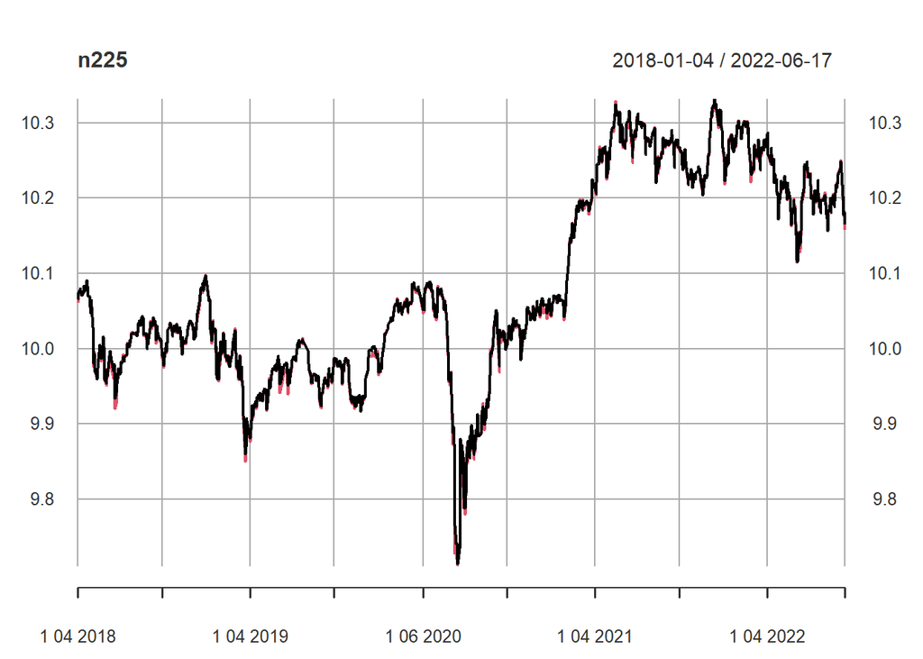

```r
plot(n225) # 時系列プロット
```

```r
summary(n225) # 記述統計量
```

```
##      Index              log.n225s        log.n225f
##  Min.   :2018-01-04   Min.   : 9.714   Min.   : 9.712
##  1st Qu.:2019-02-13   1st Qu.: 9.986   1st Qu.: 9.985
##  Median :2020-03-30   Median :10.049   Median :10.048
##  Mean   :2020-03-26   Mean   :10.087   Mean   :10.085
##  3rd Qu.:2021-05-11   3rd Qu.:10.220   3rd Qu.:10.220
##  Max.   :2022-06-17   Max.   :10.331   Max.   :10.329
```

```r
cov(n225) # 共分散行列
```

```
##            log.n225s  log.n225f
## log.n225s 0.01691668 0.01698954
## log.n225f 0.01698954 0.01707470
```

```r
cor(n225) # 相関行列
```

```
##           log.n225s log.n225f
## log.n225s 1.0000000 0.9996491
## log.n225f 0.9996491 1.0000000
```

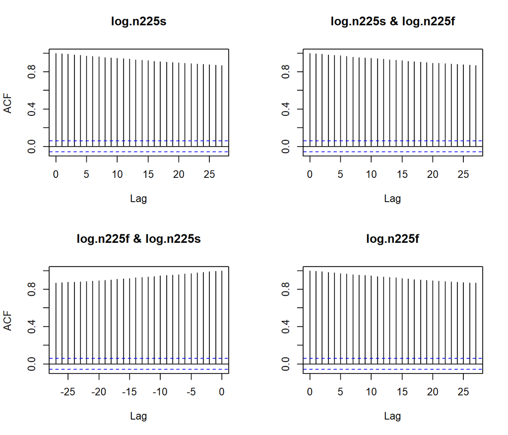

```r
acf(n225) # コレログラム
```

# 4 単位根検定

まず, 日経平均株価に対して ADF 検定を行う.

```r
ur.n225s <- ur.df(n225$log.n225s, # 標本
              type = "trend", # Type 3
              lags = 20, # AR の最大次数
              selectlags = "BIC") # BIC を用いて AR 次数を決定
ur.n225s # 検定統計量の値
```

```
##
## ###############################################################
## # Augmented Dickey-Fuller Test Unit Root / Cointegration Test #
## ###############################################################
##
## The value of the test statistic is: -2.8293 2.6965 4.017
```

```r
ur.n225s@cval # 棄却域
```

```
##       1pct  5pct 10pct
## tau3 -3.96 -3.41 -3.12
## phi2  6.09  4.68  4.03
## phi3  8.27  6.25  5.34
```

tau3 の値 $-2.829$ は $-3.12$ より大きいので, 有意水準 $10 \%$ で帰無仮説を棄却できない. よって, 帰無仮説を受容し, 日経平均株価は単位根過程であると判断する.

次に, 日経 225 先物に対して ADF 検定を行う.

```r
ur.n225f <- ur.df(n225$log.n225f, # 標本
              type = "trend", # Type 3
              lags = 20, # AR の最大次数
              selectlags = "BIC") # BIC を用いて AR 次数を決定
ur.n225f # 検定統計量の値
```

```
##
## ###############################################################
## # Augmented Dickey-Fuller Test Unit Root / Cointegration Test #
## ###############################################################
##
## The value of the test statistic is: -2.6895 2.4387 3.6315
```

```r
ur.n225f@cval # 棄却域
```

```
##       1pct  5pct 10pct
## tau3 -3.96 -3.41 -3.12
## phi2  6.09  4.68  4.03
## phi3  8.27  6.25  5.34
```

# 5 推定

パッケージ vars を用いて分析を行う.

## 5.1 次数の決定

情報量基準を用いて, VAR モデルの次数を決定する.

```r
(IC <- VARselect(n225, # 標本
                 lag.max = 20)) # 最大次数
```

```
## $selection
## AIC(n)  HQ(n)  SC(n) FPE(n)
##     15      9      2     15
##
## $criteria
##                    1             2             3             4             5
## AIC(n) -2.021523e+01 -2.030044e+01 -2.030829e+01 -2.030986e+01 -2.031873e+01
## HQ(n)  -2.020462e+01 -2.028275e+01 -2.028354e+01 -2.027803e+01 -2.027982e+01
## SC(n)  -2.018722e+01 -2.025376e+01 -2.024295e+01 -2.022585e+01 -2.021605e+01
## FPE(n)  1.662029e-09  1.526276e-09  1.514329e-09  1.511961e-09  1.498607e-09
##                    6             7             8             9            10
## AIC(n) -2.032342e+01 -2.033688e+01 -2.033932e+01 -2.035109e+01 -2.035618e+01
## HQ(n)  -2.027744e+01 -2.028383e+01 -2.027919e+01 -2.028388e+01 -2.028190e+01
## SC(n)  -2.020207e+01 -2.019686e+01 -2.018063e+01 -2.017373e+01 -2.016015e+01
## FPE(n)  1.491593e-09  1.471658e-09  1.468074e-09  1.450903e-09  1.443538e-09
##                   11            12            13            14            15
## AIC(n) -2.035907e+01 -2.035818e+01 -2.036460e+01 -2.036307e+01 -2.037362e+01
## HQ(n)  -2.027772e+01 -2.026975e+01 -2.026910e+01 -2.026050e+01 -2.026397e+01
## SC(n)  -2.014437e+01 -2.012481e+01 -2.011257e+01 -2.009236e+01 -2.008424e+01
## FPE(n)  1.439375e-09  1.440664e-09  1.431447e-09  1.433650e-09  1.418613e-09
##                   16            17            18            19            20
## AIC(n) -2.036679e+01 -2.036159e+01 -2.036027e+01 -2.035281e+01 -2.034732e+01
## HQ(n)  -2.025007e+01 -2.023780e+01 -2.022940e+01 -2.021487e+01 -2.020230e+01
## SC(n)  -2.005874e+01 -2.003488e+01 -2.001488e+01 -1.998876e+01 -1.996460e+01
## FPE(n)  1.428344e-09  1.435798e-09  1.437717e-09  1.448483e-09  1.456482e-09
```

AIC では VAR(15), BIC では VAR(2) が選択される.

## 5.2 共和分検定

ここでは, AIC の結果を用いて検定を行う.

```r
n225.vec1 <- ca.jo(n225, # 標本
                 ecdet = "const", # 共和分関係に定数項を含める
                 type = "eigen", # 最大固有値検定
                 K = IC$selection[1], # AIC による次数
                 spec = "transitory") # 均衡からのずれの影響は短期的
n225.vec2 <- ca.jo(n225, # 標本
                 ecdet = "const", # 共和分関係に定数項を含める
                 type = "trace", # トレース検定
                 K = IC$selection[1], # AIC による次数
                 spec = "transitory") # 均衡からのずれの影響は短期的
summary(n225.vec1) # 最大固有値検定の結果
```

```
##
## ######################
## # Johansen-Procedure #
## ######################
##
## Test type: maximal eigenvalue statistic (lambda max) , without linear trend and constant in cointegration
##
## Eigenvalues (lambda):
## [1] 6.766888e-02 2.309600e-03 2.115805e-18
##
## Values of teststatistic and critical values of test:
##
##           test 10pct  5pct  1pct
## r <= 1 |  2.47  7.52  9.24 12.97
## r = 0  | 74.97 13.75 15.67 20.20
##
## Eigenvectors, normalised to first column:
## (These are the cointegration relations)
##
##              log.n225s.l1 log.n225f.l1   constant
## log.n225s.l1   1.00000000    1.0000000  1.0000000
## log.n225f.l1  -0.99681747   -0.8309482 -0.9153697
## constant      -0.03340764   -1.7092321 -0.7846096
##
## Weights W:
## (This is the loading matrix)
##
##             log.n225s.l1 log.n225f.l1      constant
## log.n225s.d   0.02771587  -0.02714977  1.266799e-14
## log.n225f.d   0.51262915  -0.02808359 -1.434681e-12
```

```r
summary(n225.vec2) # トレース検定の結果
```

```
##
## ######################
## # Johansen-Procedure #
## ######################
##
## Test type: trace statistic , without linear trend and constant in cointegration
##
## Eigenvalues (lambda):
## [1] 6.766888e-02 2.309600e-03 2.115805e-18
##
## Values of teststatistic and critical values of test:
##
##           test 10pct  5pct  1pct
## r <= 1 |  2.47  7.52  9.24 12.97
## r = 0  | 77.45 17.85 19.96 24.60
##
## Eigenvectors, normalised to first column:
## (These are the cointegration relations)
##
##              log.n225s.l1 log.n225f.l1   constant
## log.n225s.l1   1.00000000    1.0000000  1.0000000
## log.n225f.l1  -0.99681747   -0.8309482 -0.9153697
## constant      -0.03340764   -1.7092321 -0.7846096
##
## Weights W:
## (This is the loading matrix)
##
##             log.n225s.l1 log.n225f.l1      constant
## log.n225s.d   0.02771587  -0.02714977  1.266799e-14
## log.n225f.d   0.51262915  -0.02808359 -1.434681e-12
```

```r
# 参考
n225.vec3 <- ca.jo(n225, # 標本
                 ecdet = "const", # 共和分関係に定数項を含める
                 type = "eigen", # 最大固有値検定
                 K = IC$selection[3], # BIC による次数
                 spec = "longrun") # 均衡からのずれの影響は長期的
```

最大固有値検定において, 検定統計量の値 $74.97$ は $20.2$ より大きいので, 有意水準 $1 \%$ で帰無仮説 (共和分関係はない) を棄却できる. よって, 共和分関係があると判断する.

トレース検定において, 検定統計量の値 $77.45$ は $24.6$ より大きいので, 有意水準 $1 \%$ で帰無仮説 (共和分関係はない) を棄却できる. よって, 共和分関係があると判断する.

共和分ベクトルは次である.

```r
cajorls(n225.vec1, r = 1)$beta
```

```
##                     ect1
## log.n225s.l1  1.00000000
## log.n225f.l1 -0.99681747
## constant     -0.03340764
```

```r
# cajorls(n225.vec2, r = 1)$beta # 同じ結論が得られる
```

よって, 次の均衡関係 (共和分関係) があると判断できる.
$$\log (\text{N225s}) = 0.03341 + 0.9968 \log (\text{N225f})$$

比較の為, 日経 225 先物で規準化する.
$$\log (\text{N225f}) = -0.03351 + 1.003 \log (\text{N225s})$$

## 5.3 モデル診断

VECM を VAR に戻す.

```r
n225.var1 <- vec2var(n225.vec1)
```

残差の自己相関を調べ, モデルが妥当かどうかを診断する. かばん検定を行う.

```r
m <- 10 # 最大ラグ
lag <- 1:m + IC$selection[1] # ラグ (1, ..., m) + p
res.port1 <- sapply(lag, port.v, x = n225.var1) # x に対して各 lag の port.v を計算

digits <- c(0, 2, 0, 4) # 少数点以下の最大表示桁数
col.names <- c("$m$", "$Q(m)$", "自由度", "$p$ 値") # 列名
# 表を作成
knitr::kable(t(res.port1), # 転置
             digits = digits, # 少数点以下の最大表示桁数
             col.names = col.names, # 列名
             caption = "VECM の残差に対するかばん検定", # 表題
             format.args = list(scientific = FALSE)) # 指数表記をしない
```

VECM の残差に対するかばん検定

| $m$ | $Q(m)$ | 自由度 | $p$ 値 |
| --- | --- | --- | --- |
| 16 | 5.54 | 6 | 0.4767 |
| 17 | 6.74 | 10 | 0.7493 |
| 18 | 13.73 | 14 | 0.4697 |
| 19 | 14.52 | 18 | 0.6948 |
| 20 | 16.58 | 22 | 0.7863 |
| 21 | 18.77 | 26 | 0.8460 |
| 22 | 19.58 | 30 | 0.9269 |
| 23 | 21.71 | 34 | 0.9491 |
| 24 | 24.72 | 38 | 0.9525 |
| 25 | 25.61 | 42 | 0.9783 |

全てにおいて $p$ 値が $0.05$ より大きいので, 有意水準 $5 \%$ で帰無仮説を棄却できない. つまり, 残差に自己相関があると判断できないので, VECM モデルは妥当である．

# 6 分析

## 6.1 インパルス応答関数

$1$ 標準偏差のショックを与えたときの直交化 IRF を計算しプロットする.

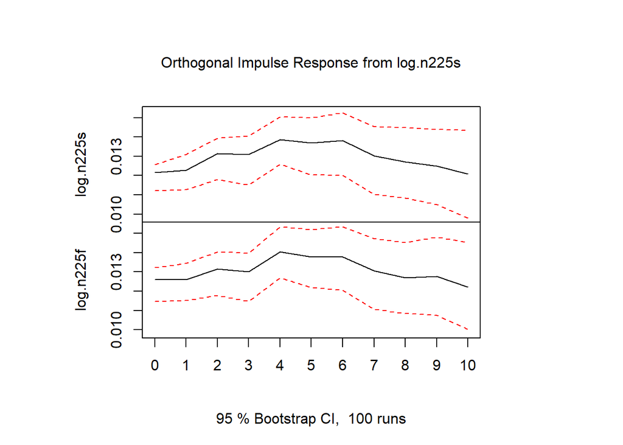

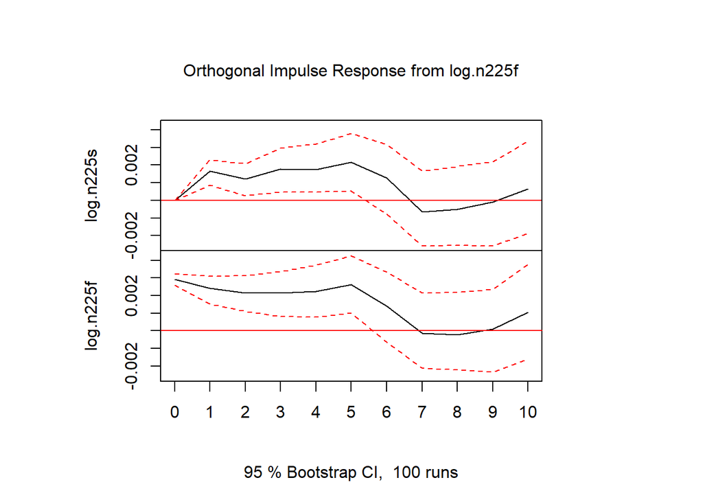

```r
n225.irf1 <- irf(n225.var1) # IRF
plot(n225.irf1) # IRF をプロット
```

# 7 補足

## 7.1 VAR モデルを用いた分析

```r
M1 <- VAR(n225, lag.max = 20, ic = "AIC") # AIC によるモデルの推定
```

AIC により推定される VAR(15) を Model 1 とし, IRF を計算しプロットする. VECM と同じ結論が得られる.

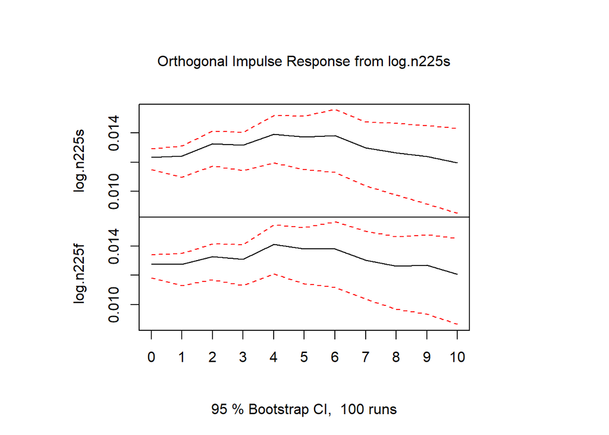

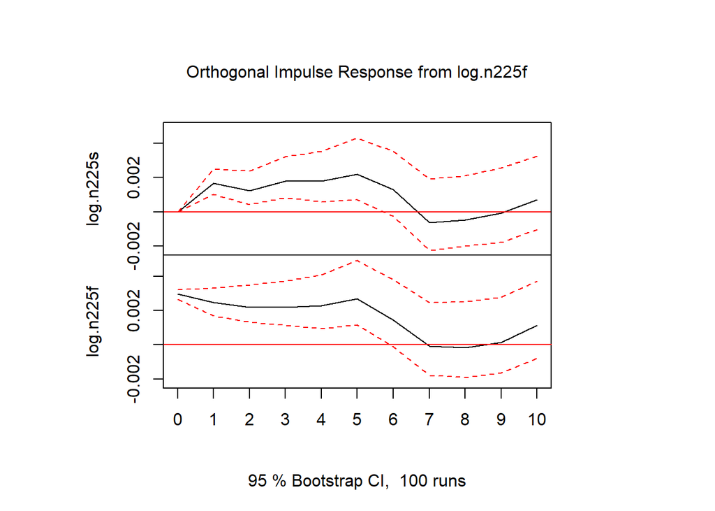

```r
M1.irf <- irf(M1) # IRF
plot(M1.irf) # IRF をプロット
```

## 7.2 対数収益率を用いた分析

対数収益率 (%) に変換する.

```r
n225s.r <- diff(n225$log.n225s) * 100 # 日経平均株価
n225f.r <- diff(n225$log.n225f) * 100 # 日経 225 先物
n225.r <- cbind(n225s.r, n225f.r) # データを結合
names(n225.r) <- c("log.return.n225s", "log.return.n225f") # 名称を変更
sum(is.na(n225.r)) # 欠損数
```

```
## [1] 2
```

```r
n225.r <- na.omit(n225.r) # 欠損値を削除
```

### 7.2.1 時系列プロット, 記述統計量, コレログラム

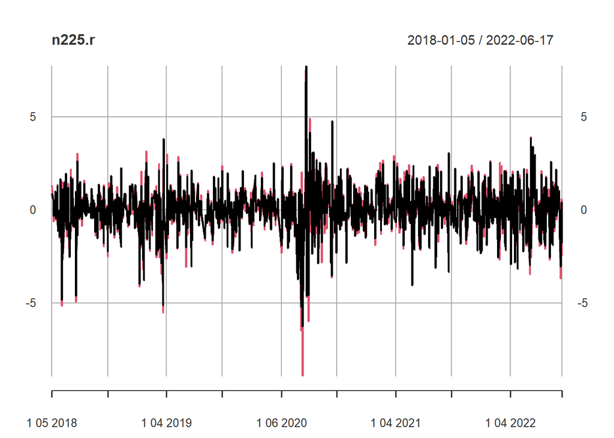

```r
plot(n225.r) # 時系列プロット
```

```r
summary(n225.r) # 記述統計量
```

```
##      Index            log.return.n225s   log.return.n225f
##  Min.   :2018-01-05   Min.   :-6.27357   Min.   :-8.939091
##  1st Qu.:2019-02-13   1st Qu.:-0.61097   1st Qu.:-0.660060
##  Median :2020-03-30   Median : 0.06223   Median : 0.035945
##  Mean   :2020-03-27   Mean   : 0.00917   Mean   : 0.008896
##  3rd Qu.:2021-05-11   3rd Qu.: 0.69585   3rd Qu.: 0.776487
##  Max.   :2022-06-17   Max.   : 7.73137   Max.   : 7.499254
```

```r
cov(n225.r) # 共分散行列
```

```
##                  log.return.n225s log.return.n225f
## log.return.n225s         1.612490         1.621849
## log.return.n225f         1.621849         1.779400
```

```r
cor(n225.r) # 相関行列
```

```
##                  log.return.n225s log.return.n225f
## log.return.n225s        1.0000000        0.9574696
## log.return.n225f        0.9574696        1.0000000
```

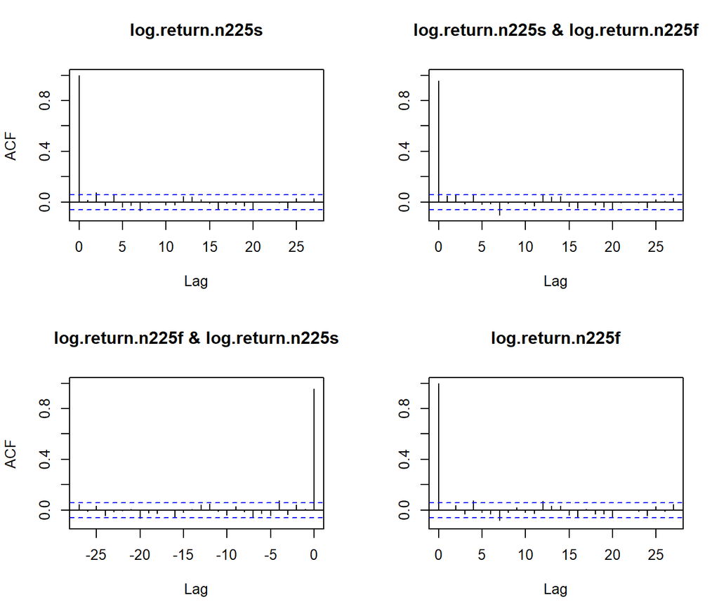

```r
acf(n225.r) # コレログラム
```

### 7.2.2 次数の決定

情報量基準を用いて, VAR モデルの次数を決定する.

```r
(IC.r <- VARselect(n225.r)) # 情報量基準
```

```
## $selection
## AIC(n)  HQ(n)  SC(n) FPE(n)
##      9      6      6      9
##
## $criteria
##                 1          2          3          4          5          6
## AIC(n) -1.7234281 -1.7730429 -1.8016800 -1.8337791 -1.8384900 -1.8719404
## HQ(n)  -1.7128926 -1.7554837 -1.7770972 -1.8021727 -1.7998598 -1.8262866
## SC(n)  -1.6956116 -1.7266821 -1.7367750 -1.7503298 -1.7364963 -1.7514025
## FPE(n)  0.1784533  0.1698155  0.1650215  0.1598086  0.1590577  0.1538252
##                 7          8         9         10
## AIC(n) -1.8756801 -1.8788423 -1.887566 -1.8838759
## HQ(n)  -1.8230026 -1.8191411 -1.820842 -1.8101275
## SC(n)  -1.7365978 -1.7212157 -1.711396 -1.6891608
## FPE(n)  0.1532513  0.1527677  0.151441  0.1520013
```

AIC では VAR(9), BIC では VAR(6) が選択される.

### 7.2.3 パラメータの推定

AIC の結果を用いて推定を行う.

```r
M1.r <- VAR(n225.r, lag.max = 10, ic = "AIC") # AIC によるモデルの推定
```

AIC により推定される VAR(9) を Model 1r とする. 残差の自己相関を調べ, モデルが妥当かどうかを診断する. かばん検定を行う.

```r
m <- 10 # 最大ラグ
lag <- 1:m + IC$selection[1] # ラグ (1, ..., m) + p
res.port1 <- sapply(lag, port.v, x = M1.r) # x に対して各 lag の port.v を計算

digits <- c(0, 2, 0, 4) # 少数点以下の最大表示桁数
col.names <- c("$m$", "$Q(m)$", "自由度", "$p$ 値") # 列名
# 表を作成
knitr::kable(t(res.port1), # 転置
             digits = digits, # 少数点以下の最大表示桁数
             col.names = col.names, # 列名
             caption = "VECM の残差に対するかばん検定", # 表題
             format.args = list(scientific = FALSE)) # 指数表記をしない
```

VECM の残差に対するかばん検定

| $m$ | $Q(m)$ | 自由度 | $p$ 値 |
| --- | --- | --- | --- |
| 16 | 72.39 | 28 | 0.0000 |
| 17 | 72.76 | 32 | 0.0001 |
| 18 | 81.77 | 36 | 0.0000 |
| 19 | 82.74 | 40 | 0.0001 |
| 20 | 85.59 | 44 | 0.0002 |
| 21 | 86.59 | 48 | 0.0005 |
| 22 | 87.14 | 52 | 0.0016 |
| 23 | 91.29 | 56 | 0.0020 |
| 24 | 92.96 | 60 | 0.0041 |
| 25 | 95.03 | 64 | 0.0071 |

全てにおいて $p$ 値が $0.01$ より小さいので, 有意水準 $1 \%$ で帰無仮説を棄却できる. つまり, 残差に自己相関があると判断できるので, モデルは妥当でない．

共和分関係があるから, 差分系列に対する結果は VECM と大きく異なる. モデルが妥当である場合は, 均衡関係を考慮しない短期的な関係が得られる.

## 7.3 回帰分析

```r
lm1 <- lm(n225$log.n225f ~ n225$log.n225s) # 回帰分析
summary(lm1) # 結果を表示
```

```
##
## Call:
## lm(formula = n225$log.n225f ~ n225$log.n225s)
##
## Residuals:
##       Min        1Q    Median        3Q       Max
## -0.034813 -0.001033  0.000602  0.001864  0.012786
##
## Coefficients:
##                  Estimate Std. Error  t value Pr(>|t|)
## (Intercept)    -0.0447208  0.0081577   -5.482 5.23e-08 ***
## n225$log.n225s  1.0043072  0.0008087 1241.873  < 2e-16 ***
## ---
## Signif. codes:  0 '***' 0.001 '**' 0.01 '*' 0.05 '.' 0.1 ' ' 1
##
## Residual standard error: 0.003463 on 1083 degrees of freedom
## Multiple R-squared:  0.9993, Adjusted R-squared:  0.9993
## F-statistic: 1.542e+06 on 1 and 1083 DF,  p-value: < 2.2e-16
```

共和分関係があるから, 共和分関係とほぼ同じ結論が得られる. しかし, 見せかけの回帰の批判に反論することが困難であるので, 共和分検定を行うべきである. さらに, $p$ 値の計算方法も異なるので注意が必要である.
$$\log (\text{N225f}) = -0.04472 + 1.004 \log (\text{N225s}) + \varepsilon$$

次に, 対数収益率を用いて回帰分析を行う.

```r
lm1.r <- lm(n225.r$log.return.n225f ~ n225.r$log.return.n225s) # 回帰分析
summary(lm1.r) # 結果を表示
```

```
##
## Call:
## lm(formula = n225.r$log.return.n225f ~ n225.r$log.return.n225s)
##
## Residuals:
##     Min      1Q  Median      3Q     Max
## -3.3248 -0.1532  0.0050  0.1537  3.0074
##
## Coefficients:
##                           Estimate Std. Error t value Pr(>|t|)
## (Intercept)             -0.0003269  0.0116958  -0.028    0.978
## n225.r$log.return.n225s  1.0058039  0.0092145 109.154   <2e-16 ***
## ---
## Signif. codes:  0 '***' 0.001 '**' 0.01 '*' 0.05 '.' 0.1 ' ' 1
##
## Residual standard error: 0.3851 on 1082 degrees of freedom
## Multiple R-squared:  0.9167, Adjusted R-squared:  0.9167
## F-statistic: 1.191e+04 on 1 and 1082 DF,  p-value: < 2.2e-16
```

対数収益率は定常であるから, 通常の分析が可能であり, 結論は次である.
$$\Delta \log (\text{N225f}) = 1.006 \Delta \log (\text{N225s}) +
\varepsilon$$